# Final Project: Analyzing U.S. Election County Data

Daniel Smolyak

5/16/2018

# Introduction

With the recent U.S. presidential election behind us and and a midterm election in the near future, it is easy to focus on the anecdotal headlines and stories on individual voters, individual districts, or even individual states. However, a thorough data analysis of the characteristics of each and every county and how they voted in each election can provide us with a clearer and more accurate idea of just what drives the general trends in political leanings, regardless of these specific anecdotes.

Simultaneously, this will be a tutorial in data analysis using R. We will first examine how to collect raw data on these county characteristics and votes. Then, we will go through the processing of this data in order to prepare it for analysis. Then, we will visualize the data in order to conduct exploratory analysis. From there, we will focus in and analyze patterns we’ve discovered in the visualization. And from these patterns, we will draw conclusions on general trends within the U.S. electorate. And using these general trends, we hope to draw insights on why certain areas of the country lean more Democratic or Republican, in order to better understand the overall results of past and upcoming elections.

[figure not shown]

# Setup

Before we start, you’ll want to make sure you have the proper packages installed and imported as shown below. Some common packages in R include tidyverse, dplyr, and stringr, among others.

```r
library(tidyverse)
library(dplyr)
library(stringr)
```

# Data Collection

The data used for this project can be found online at this [kaggle repository](https://www.kaggle.com/joelwilson/identity-politics-in-the-2016-election/data). At this repository, we find two csv files, one on each U.S. county’s [demographic characteristics](https://www.kaggle.com/joelwilson/2012-2016-presidential-elections/downloads/county_facts.csv/2) and another on its [voting behavior](https://www.kaggle.com/joelwilson/2012-2016-presidential-elections/downloads/US_County_Level_Presidential_Results_12-16.csv/2).

So the first step in collecting this data is of course to download the datasets, by clicking on the link above. Then, after placing these csv files in the same folder as your analysis, we can execute the code below, which converts csv files into useable data in R, in the form of a data frame.

```r
path <- "./county_facts.csv"
county_data <- read_csv(path)
county_data
```

```
## # A tibble: 3,195 x 54
##     fips area_name      state_abbreviation PST045214 PST040210 PST120214
##    <int> <chr>          <chr>                  <int>     <int>     <dbl>
##  1     0 United States  <NA>               318857056 308758105     3.30
##  2  1000 Alabama        <NA>                 4849377   4780127     1.40
##  3  1001 Autauga County AL                     55395     54571     1.50
##  4  1003 Baldwin County AL                    200111    182265     9.80
##  5  1005 Barbour County AL                     26887     27457    -2.10
##  6  1007 Bibb County    AL                     22506     22919    -1.80
##  7  1009 Blount County  AL                     57719     57322     0.700
##  8  1011 Bullock County AL                     10764     10915    -1.40
##  9  1013 Butler County  AL                     20296     20946    -3.10
## 10  1015 Calhoun County AL                    115916    118586    -2.30
## # ... with 3,185 more rows, and 48 more variables: POP010210 <int>,
## #   AGE135214 <dbl>, AGE295214 <dbl>, AGE775214 <dbl>, SEX255214 <dbl>,
## #   RHI125214 <dbl>, RHI225214 <dbl>, RHI325214 <dbl>, RHI425214 <dbl>,
## #   RHI525214 <dbl>, RHI625214 <dbl>, RHI725214 <dbl>, RHI825214 <dbl>,
## #   POP715213 <dbl>, POP645213 <dbl>, POP815213 <dbl>, EDU635213 <dbl>,
## #   EDU685213 <dbl>, VET605213 <int>, LFE305213 <dbl>, HSG010214 <int>,
## #   HSG445213 <dbl>, HSG096213 <dbl>, HSG495213 <int>, HSD410213 <int>,
## #   HSD310213 <dbl>, INC910213 <int>, INC110213 <int>, PVY020213 <dbl>,
## #   BZA010213 <int>, BZA110213 <int>, BZA115213 <dbl>, NES010213 <int>,
## #   SBO001207 <int>, SBO315207 <dbl>, SBO115207 <dbl>, SBO215207 <dbl>,
## #   SBO515207 <dbl>, SBO415207 <dbl>, SBO015207 <dbl>, MAN450207 <dbl>,
## #   WTN220207 <dbl>, RTN130207 <dbl>, RTN131207 <int>, AFN120207 <int>,
## #   BPS030214 <int>, LND110210 <dbl>, POP060210 <dbl>
```

```r
path <- "./US_County_Level_Presidential_Results_12-16.csv"
election_data <- read_csv(path)
election_data
```

```
## # A tibble: 3,141 x 21
##       X1 combined_fips votes_dem_2016 votes_gop_2016 total_votes_2016
##    <int>         <int>          <dbl>          <dbl>            <dbl>
##  1     0          2013          93003         130413           246588
##  2     1          2016          93003         130413           246588
##  3     2          2020          93003         130413           246588
##  4     3          2050          93003         130413           246588
##  5     4          2060          93003         130413           246588
##  6     5          2068          93003         130413           246588
##  7     6          2070          93003         130413           246588
##  8     7          2090          93003         130413           246588
##  9     8          2100          93003         130413           246588
## 10     9          2105          93003         130413           246588
## # ... with 3,131 more rows, and 16 more variables: per_dem_2016 <dbl>,
## #   per_gop_2016 <dbl>, diff_2016 <int>, per_point_diff_2016 <dbl>,
## #   state_abbr <chr>, county_name <chr>, FIPS <chr>,
## #   total_votes_2012 <dbl>, votes_dem_2012 <dbl>, votes_gop_2012 <dbl>,
## #   county_fips <chr>, state_fips <chr>, per_dem_2012 <dbl>,
## #   per_gop_2012 <dbl>, diff_2012 <dbl>, per_point_diff_2012 <dbl>
```

# Basic Data Manipulation

Now, we may explore these specific data frames in a variety of ways to get a general sense of what is contained within them. For example we might ask how many rows (counties) there are:

```r
nrow(county_data)
```

```
## [1] 3195
```

Or we might ask what are and how many columns (attributes) do we have:

```r
colnames(county_data)
```

```
##  [1] "fips"               "area_name"          "state_abbreviation"
##  [4] "PST045214"          "PST040210"          "PST120214"
##  [7] "POP010210"          "AGE135214"          "AGE295214"
## [10] "AGE775214"          "SEX255214"          "RHI125214"
## [13] "RHI225214"          "RHI325214"          "RHI425214"
## [16] "RHI525214"          "RHI625214"          "RHI725214"
## [19] "RHI825214"          "POP715213"          "POP645213"
## [22] "POP815213"          "EDU635213"          "EDU685213"
## [25] "VET605213"          "LFE305213"          "HSG010214"
## [28] "HSG445213"          "HSG096213"          "HSG495213"
## [31] "HSD410213"          "HSD310213"          "INC910213"
## [34] "INC110213"          "PVY020213"          "BZA010213"
## [37] "BZA110213"          "BZA115213"          "NES010213"
## [40] "SBO001207"          "SBO315207"          "SBO115207"
## [43] "SBO215207"          "SBO515207"          "SBO415207"
## [46] "SBO015207"          "MAN450207"          "WTN220207"
## [49] "RTN130207"          "RTN131207"          "AFN120207"
## [52] "BPS030214"          "LND110210"          "POP060210"
```

And as the above column names may seem pretty archaic, we have thankfully also been provided with a dictionary that maps these names to their meanings.

```r
path <- "./county_facts_dictionary.csv"
county_dict <- read_csv(path)
county_dict
```

```
## # A tibble: 51 x 2
##    column_name description
##    <chr>       <chr>
##  1 PST045214   Population, 2014 estimate
##  2 PST040210   Population, 2010 (April 1) estimates base
##  3 PST120214   Population, percent change - April 1, 2010 to July 1, 2014
##  4 POP010210   Population, 2010
##  5 AGE135214   Persons under 5 years, percent, 2014
##  6 AGE295214   Persons under 18 years, percent, 2014
##  7 AGE775214   Persons 65 years and over, percent, 2014
##  8 SEX255214   Female persons, percent, 2014
##  9 RHI125214   White alone, percent, 2014
## 10 RHI225214   Black or African American alone, percent, 2014
## # ... with 41 more rows
```

Now that we have a general understanding of what lies within our data frame, let’s also introduce some methods for searching for specifics within the data. For example, we can choose to look at only certain attributes, using the “select” command.

```r
select(county_data, area_name, PST045214, SEX255214)
```

```
## # A tibble: 3,195 x 3
##    area_name      PST045214 SEX255214
##    <chr>              <int>     <dbl>
##  1 United States  318857056      50.8
##  2 Alabama          4849377      51.5
##  3 Autauga County     55395      51.4
##  4 Baldwin County    200111      51.2
##  5 Barbour County     26887      46.6
##  6 Bibb County        22506      45.9
##  7 Blount County      57719      50.5
##  8 Bullock County     10764      45.3
##  9 Butler County      20296      53.6
## 10 Calhoun County    115916      51.8
## # ... with 3,185 more rows
```

Or we can choose to look at certain rows (entities) that fit a specific description or condition. For instance, the code below returns us the row with our very own Prince George’s County.

```r
filter(county_data, area_name == "Prince George's County")
```

```
## # A tibble: 1 x 54
##    fips area_name state_abbreviat… PST045214 PST040210 PST120214 POP010210
##   <int> <chr>     <chr>                <int>     <int>     <dbl>     <int>
## 1 24033 Prince G… MD                  904430    863519      4.70    863420
## # ... with 47 more variables: AGE135214 <dbl>, AGE295214 <dbl>,
## #   AGE775214 <dbl>, SEX255214 <dbl>, RHI125214 <dbl>, RHI225214 <dbl>,
## #   RHI325214 <dbl>, RHI425214 <dbl>, RHI525214 <dbl>, RHI625214 <dbl>,
## #   RHI725214 <dbl>, RHI825214 <dbl>, POP715213 <dbl>, POP645213 <dbl>,
## #   POP815213 <dbl>, EDU635213 <dbl>, EDU685213 <dbl>, VET605213 <int>,
## #   LFE305213 <dbl>, HSG010214 <int>, HSG445213 <dbl>, HSG096213 <dbl>,
## #   HSG495213 <int>, HSD410213 <int>, HSD310213 <dbl>, INC910213 <int>,
## #   INC110213 <int>, PVY020213 <dbl>, BZA010213 <int>, BZA110213 <int>,
## #   BZA115213 <dbl>, NES010213 <int>, SBO001207 <int>, SBO315207 <dbl>,
## #   SBO115207 <dbl>, SBO215207 <dbl>, SBO515207 <dbl>, SBO415207 <dbl>,
## #   SBO015207 <dbl>, MAN450207 <dbl>, WTN220207 <dbl>, RTN130207 <dbl>,
## #   RTN131207 <int>, AFN120207 <int>, BPS030214 <int>, LND110210 <dbl>,
## #   POP060210 <dbl>
```

We can even use the FIPS (Federal Information Processing Standard) code to find all of the counties recorded that are in Maryland, as we know that those every 1000 fips are for one state, and the result above indicates the Maryland FIPS are between 24000 and 25000.

```r
filter(county_data, fips >= 24000 & fips < 25000)
```

```
## # A tibble: 25 x 54
##     fips area_name         state_abbreviati… PST045214 PST040210 PST120214
##    <int> <chr>             <chr>                 <int>     <int>     <dbl>
##  1 24000 Maryland          <NA>                5976407   5773785     3.50
##  2 24001 Allegany County   MD                    72952     75087    -2.80
##  3 24003 Anne Arundel Cou… MD                   560133    537656     4.20
##  4 24005 Baltimore County  MD                   826925    804973     2.70
##  5 24009 Calvert County    MD                    90613     88737     2.10
##  6 24011 Caroline County   MD                    32538     33066    -1.60
##  7 24013 Carroll County    MD                   167830    167138     0.400
##  8 24015 Cecil County      MD                   102383    101108     1.30
##  9 24017 Charles County    MD                   154747    146551     5.60
## 10 24019 Dorchester County MD                    32578     32618    -0.100
## # ... with 15 more rows, and 48 more variables: POP010210 <int>,
## #   AGE135214 <dbl>, AGE295214 <dbl>, AGE775214 <dbl>, SEX255214 <dbl>,
## #   RHI125214 <dbl>, RHI225214 <dbl>, RHI325214 <dbl>, RHI425214 <dbl>,
## #   RHI525214 <dbl>, RHI625214 <dbl>, RHI725214 <dbl>, RHI825214 <dbl>,
## #   POP715213 <dbl>, POP645213 <dbl>, POP815213 <dbl>, EDU635213 <dbl>,
## #   EDU685213 <dbl>, VET605213 <int>, LFE305213 <dbl>, HSG010214 <int>,
## #   HSG445213 <dbl>, HSG096213 <dbl>, HSG495213 <int>, HSD410213 <int>,
## #   HSD310213 <dbl>, INC910213 <int>, INC110213 <int>, PVY020213 <dbl>,
## #   BZA010213 <int>, BZA110213 <int>, BZA115213 <dbl>, NES010213 <int>,
## #   SBO001207 <int>, SBO315207 <dbl>, SBO115207 <dbl>, SBO215207 <dbl>,
## #   SBO515207 <dbl>, SBO415207 <dbl>, SBO015207 <dbl>, MAN450207 <dbl>,
## #   WTN220207 <dbl>, RTN130207 <dbl>, RTN131207 <int>, AFN120207 <int>,
## #   BPS030214 <int>, LND110210 <dbl>, POP060210 <dbl>
```

# Data Linkage

Now, to make this data useable for comparison of county demographics to county voting trends, we need to combine these two data frames. We will be doing this two-table operations, specifically by “joining” the demographics table and the voting table on their matching value for FIPS. Such operations are also frequently done in SQL, where information is separated in a database into tables. You can read more about these two table operations [here](https://www.w3schools.com/sql/sql_join.asp), but we will show our specific use-case below.

```r
total_df <- county_data %>%
  inner_join(election_data, by = c("fips" = "combined_fips"))
total_df
```

```
## # A tibble: 3,141 x 74
##     fips area_name       state_abbreviation PST045214 PST040210 PST120214
##    <int> <chr>           <chr>                  <int>     <int>     <dbl>
##  1  1001 Autauga County  AL                     55395     54571     1.50
##  2  1003 Baldwin County  AL                    200111    182265     9.80
##  3  1005 Barbour County  AL                     26887     27457    -2.10
##  4  1007 Bibb County     AL                     22506     22919    -1.80
##  5  1009 Blount County   AL                     57719     57322     0.700
##  6  1011 Bullock County  AL                     10764     10915    -1.40
##  7  1013 Butler County   AL                     20296     20946    -3.10
##  8  1015 Calhoun County  AL                    115916    118586    -2.30
##  9  1017 Chambers County AL                     34076     34170    -0.300
## 10  1019 Cherokee County AL                     26037     25986     0.200
## # ... with 3,131 more rows, and 68 more variables: POP010210 <int>,
## #   AGE135214 <dbl>, AGE295214 <dbl>, AGE775214 <dbl>, SEX255214 <dbl>,
## #   RHI125214 <dbl>, RHI225214 <dbl>, RHI325214 <dbl>, RHI425214 <dbl>,
## #   RHI525214 <dbl>, RHI625214 <dbl>, RHI725214 <dbl>, RHI825214 <dbl>,
## #   POP715213 <dbl>, POP645213 <dbl>, POP815213 <dbl>, EDU635213 <dbl>,
## #   EDU685213 <dbl>, VET605213 <int>, LFE305213 <dbl>, HSG010214 <int>,
## #   HSG445213 <dbl>, HSG096213 <dbl>, HSG495213 <int>, HSD410213 <int>,
## #   HSD310213 <dbl>, INC910213 <int>, INC110213 <int>, PVY020213 <dbl>,
## #   BZA010213 <int>, BZA110213 <int>, BZA115213 <dbl>, NES010213 <int>,
## #   SBO001207 <int>, SBO315207 <dbl>, SBO115207 <dbl>, SBO215207 <dbl>,
## #   SBO515207 <dbl>, SBO415207 <dbl>, SBO015207 <dbl>, MAN450207 <dbl>,
## #   WTN220207 <dbl>, RTN130207 <dbl>, RTN131207 <int>, AFN120207 <int>,
## #   BPS030214 <int>, LND110210 <dbl>, POP060210 <dbl>, X1 <int>,
## #   votes_dem_2016 <dbl>, votes_gop_2016 <dbl>, total_votes_2016 <dbl>,
## #   per_dem_2016 <dbl>, per_gop_2016 <dbl>, diff_2016 <int>,
## #   per_point_diff_2016 <dbl>, state_abbr <chr>, county_name <chr>,
## #   FIPS <chr>, total_votes_2012 <dbl>, votes_dem_2012 <dbl>,
## #   votes_gop_2012 <dbl>, county_fips <chr>, state_fips <chr>,
## #   per_dem_2012 <dbl>, per_gop_2012 <dbl>, diff_2012 <dbl>,
## #   per_point_diff_2012 <dbl>
```

# Vizualization

Now our data is all together in one data frame, we may begin analyzing some basic trends and patterns in the data. For instance, we can plot in a histogram the number of counties in various ranges of political leanings. We will do this by using the “per_point_diff_2016” statistic, which is the percentage differential between Democratic and Republican votes in 2016. (subtracts the Republican percentage from the Democratic percentage). Thus, counties leaning Republican will be negative while those leaning Democratic will be positive. Additionally, we include two lines to indicate where the median and mean leaning is of a county in 2016.

We do this using the ggplot package, which allows to specify what type of plot we’d like (histogram), what we’d like as the x-variable (per_point_diff_2016) and the other vertical that are plotted below, using geom_vline.

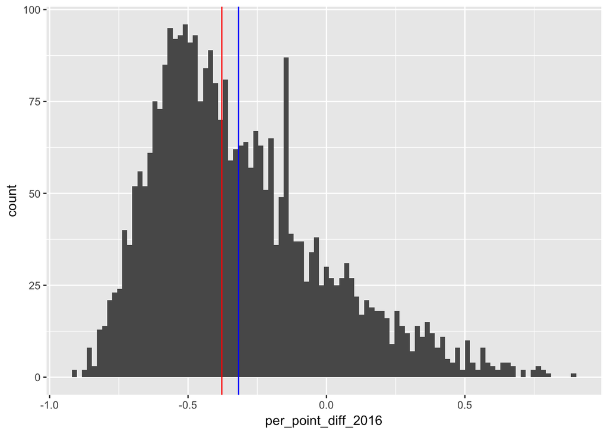

```r
total_df %>%
  ggplot(aes(x=per_point_diff_2016)) +
      geom_histogram(bins=100) +
      geom_vline(aes(xintercept=median(per_point_diff_2016)), color="red") +
      geom_vline(aes(xintercept=mean(per_point_diff_2016)), color="blue")
```

From the visualization above, it might seem like the typical voter in the U.S. leans heavily Republican, but all this visualization literally says is that the typical county leans Republican. And upon further examination, we would likely see that weighting counties by population would likely return the mean (as opposed to the median) to much closer to 0, as the highest population counties occur least often and are most often heavily Democratic.

Thus, below we calculate this “weighted lean” by simply finding the difference between the number of Democratic and Republican votes. And below we can see that the mean, which appropriately weights by population produces a slightly Democratic lean, as the popular vote in 2016 did lean Democratic, while the median, which goes purely by number of counties, leans much more heavily Republican.

```r
weight_df <- total_df %>% mutate(weighted_lean = votes_dem_2016 - votes_gop_2016)
summarize(weight_df, mean_lean = mean(weighted_lean), median_lean = median(weighted_lean))
```

```
## # A tibble: 1 x 2
##   mean_lean median_lean
##       <dbl>       <dbl>
## 1      69.4       -2833
```

Furthermore, we can plot these weights on a new histogram, as shown below.

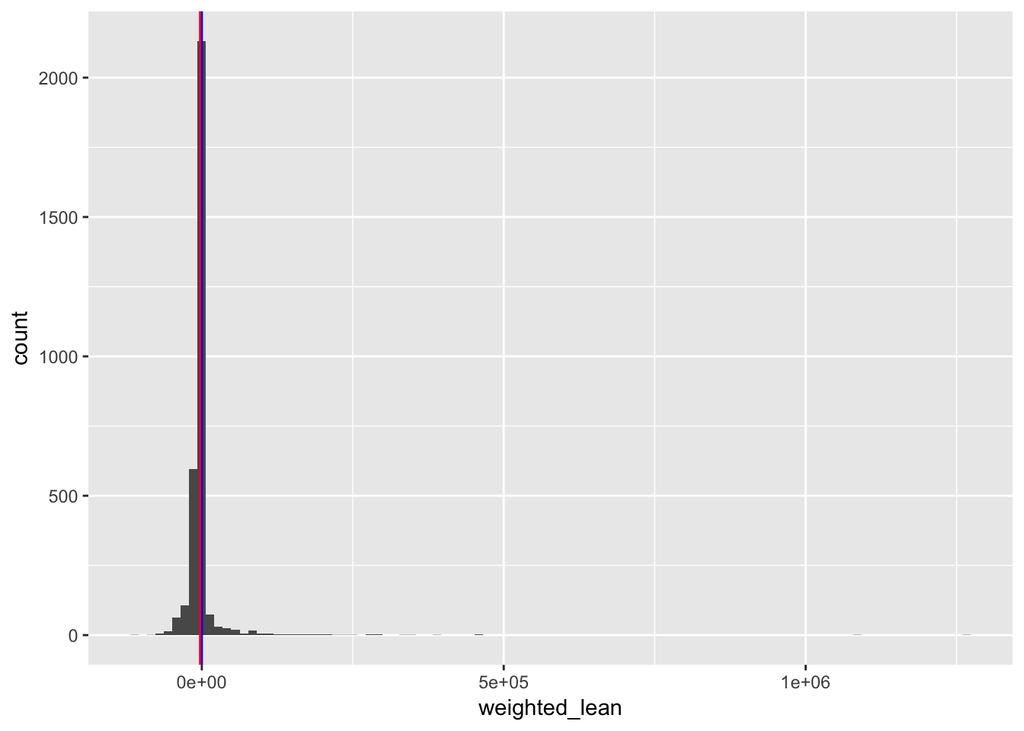

```r
weight_df %>%
  ggplot(aes(x=weighted_lean)) +
      geom_histogram(bins=100) +
      geom_vline(aes(xintercept=mean(weighted_lean)), color="blue") +
      geom_vline(aes(xintercept=median(weighted_lean)), color="red")
```

However, it is immediately visible that these weights are too far spread out to get a good feel for the data, so we now instead transform the data, using the log function. Specifically we take the log of positive values, and for negative values, we take their absolute value, then take their log, and then multiply by -1. This allows us a cleaner view of the data: we can now see the substantial difference between the mean and median. Additionally, we can see the trend suspected before, that while there are fewer Democratic leaning counties, they tend to be the most populous counties.

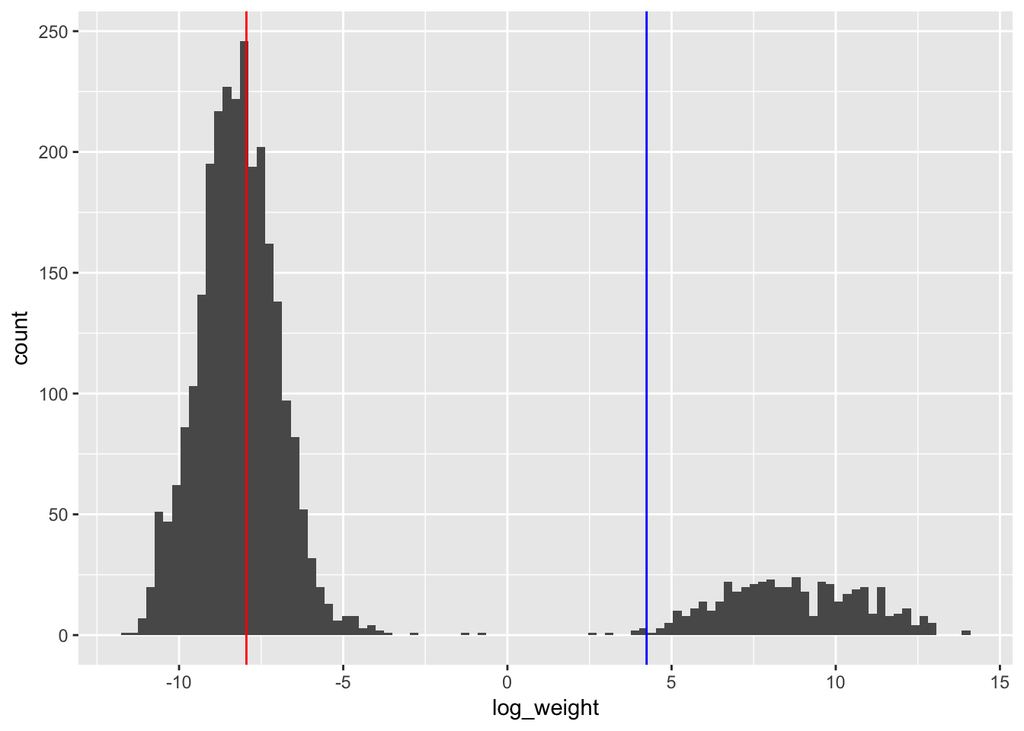

```r
weight_df %>%
  mutate(log_weight = ifelse(weighted_lean > 0, log(weighted_lean), log(abs(weighted_lean)) * -1)) %>%
  ggplot(aes(x=log_weight)) +
      geom_histogram(bins=100) +
      geom_vline(aes(xintercept=log(mean(weighted_lean))), color="blue") +
      geom_vline(aes(xintercept= (log(abs(median(weighted_lean)))) * -1), color="red")
```

# Hypothesis Testing

Next, since we have our unified data set, let’s test out what effects certain county characteristics have on political leaning. For instance, it’s often been said in the news that Donald Trump has pulled more educated voters to the left. Thus, in formal terms, we will hypothesize that an increase in the percentage of residents having a bachelor’s degree will lead to an increase in the percent differential in Democratic vs. Republican votes.

Let’s start by plotting these two variables against one another:

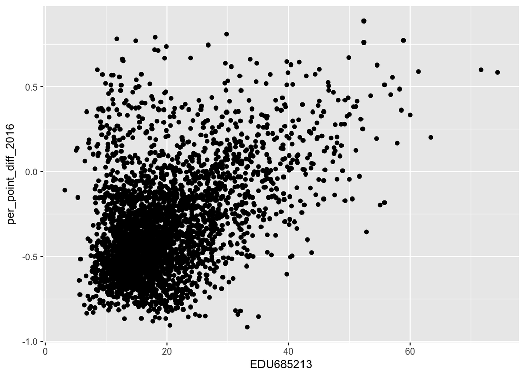

```r
total_df %>%
  ggplot(aes(x = EDU685213, y = per_point_diff_2016)) +
      geom_point()
```

From this visualization it is clear that a trend might exist, but attempt to formalize that trend. We will specifically attempt to disprove the null-hypothesis, which would be the lack of trend between these two variables. The way we will do this is by plotting a regression line: if the line goes diagonally to the upper right, there may be a trend. So let’s see:

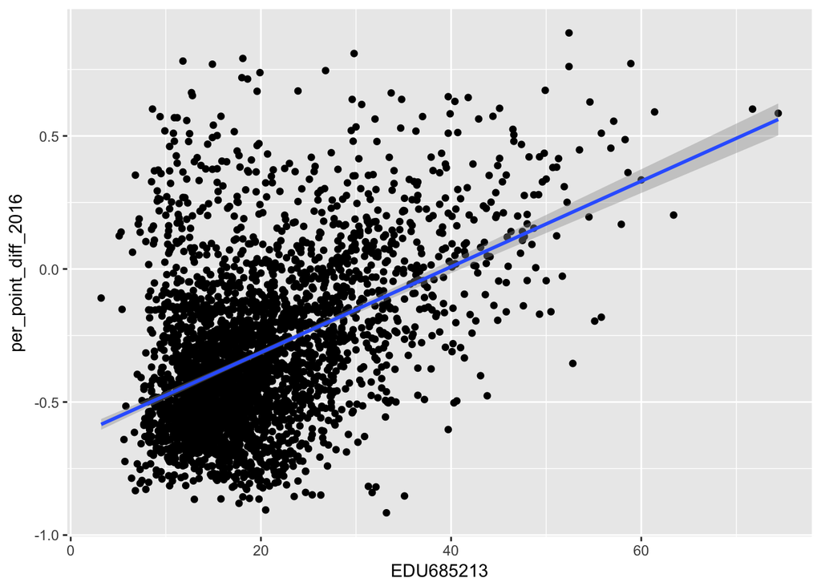

```r
total_df %>%
  ggplot(aes(x = EDU685213, y = per_point_diff_2016)) +
      geom_point() +
      geom_smooth(method = lm)
```

Awesome! We clearly see this regression line indicates an increase in education leads to an increase in Democratic leaning. Now let’s try and figure out exactly what this regression line means. Thus, we will create a linear model as shown below, determining the differential as a function of education level.

```r
education_model <- lm(total_df$per_point_diff_2016 ~ total_df$EDU685213)
broom::tidy(education_model)
```

```
##                 term    estimate    std.error statistic       p.value
## 1        (Intercept) -0.63546642 0.0119543333 -53.15783  0.000000e+00
## 2 total_df$EDU685213  0.01609466 0.0005525909  29.12581 2.724762e-165
```

This model now gives us information on two fronts. Firstly, the estimate for “total_df$EDU685213” gives us an understanding of what exactly the relation is between education and differential. Because the model states an estimate of approximately 0.016, we can interpret this to mean that for every 1% increase in education level in any given county, we can expect a 0.016 (1.6%) increase in the differential between Democratic and Republican votes. Additionally, the intercept tells us that for a county with 0% of its residents with bachelor’s degrees, the expected differential in that county would be approximately -0.635, or a strong Republican leaning.

Moreover, if we look at the p-value for both the intercept and the relationship, they are both nearly 0. Thus, as the p-value is certainly below the standard threshold of 0.05, with strong confidence, we can reject our null-hypothesis of no trend between education and political leaning.

The insight: while this regression provides no indication whatsoever of how well-informed policies on either side of the aisle are, it certainly appears that Republicans do a better job of appealing to voters of lower education levels and Democrats to voters of higher education levels. To read more on this trend you can visit this [Pew Research article](http://www.pewresearch.org/fact-tank/2016/09/15/educational-divide-in-vote-preferences-on-track-to-be-wider-than-in-recent-elections/).

# Machine Learning

Now we shall start by converting election lean into a factor (D or R).

```r
outcome_df <- total_df %>%
  mutate(result = ifelse(per_point_diff_2016 > 0, 'D', 'R')) %>%
  select(fips, result)
outcome_df
```

```
## # A tibble: 3,141 x 2
##     fips result
##    <int> <chr>
##  1  1001 R
##  2  1003 R
##  3  1005 R
##  4  1007 R
##  5  1009 R
##  6  1011 D
##  7  1013 R
##  8  1015 R
##  9  1017 R
## 10  1019 R
## # ... with 3,131 more rows
```

And then we select these four indicators, along with the outcome (which we convert to a factor).

```r
final_df <- total_df %>%
  mutate(result = ifelse(per_point_diff_2016 > 0, 'D', 'R')) %>%
  mutate(result=factor(result, levels=c("D", "R"))) %>%
  select(EDU685213, RHI125214, INC110213, POP060210, fips, result)

final_df
```

```
## # A tibble: 3,141 x 6
##    EDU685213 RHI125214 INC110213 POP060210  fips result
##        <dbl>     <dbl>     <int>     <dbl> <int> <fct>
##  1      20.9      77.9     53682      91.8  1001 R
##  2      27.7      87.1     50221     115    1003 R
##  3      13.4      50.2     32911      31.0  1005 R
##  4      12.1      76.3     36447      36.8  1007 R
##  5      12.1      96.0     44145      88.9  1009 R
##  6      12.5      26.9     32033      17.5  1011 D
##  7      14.0      53.9     29918      27.0  1013 R
##  8      16.1      75.8     39962     196    1015 R
##  9      11.8      58.3     32402      57.4  1017 R
## 10      12.8      93.0     34907      46.9  1019 R
## # ... with 3,131 more rows
```

Now, we partition this data into training and testing sets: we use the training set to train our model and then evaluate the performance of our model on the testing set.

```r
set.seed(1234)
test_random_forest_df <- final_df %>%
  group_by(result) %>%
  sample_frac(.2) %>%
  ungroup()

train_random_forest_df <- final_df %>%
  anti_join(test_random_forest_df, by="fips")
```

Now that we’ve partitioned our data, we will train a random forest (more information about these [here](https://en.wikipedia.org/wiki/Random_forest)) on our training set.

```r
library(randomForest)
rf <- randomForest(result~., data=train_random_forest_df %>% select(-fips))
rf
```

```
##
## Call:
##  randomForest(formula = result ~ ., data = train_random_forest_df %>%      select(-fips))
##                Type of random forest: classification
##                      Number of trees: 500
## No. of variables tried at each split: 2
##
##         OOB estimate of  error rate: 8.8%
## Confusion matrix:
##     D    R class.error
## D 238  152  0.38974359
## R  69 2053  0.03251649
```

```r
test_predictions <- predict(rf, newdata=test_random_forest_df %>% select(-fips))
table(pred=test_predictions, observed=test_random_forest_df$result)
```

```
##     observed
## pred   D   R
##    D  70  15
##    R  28 516
```

Thus, in this particular test, we observe an error rate of (15 + 28)/(15 + 28 + 70 + 516) = .0684 or 6.84%. While this certainly isn’t perfect, this shows that our four chosen indicators do a decent job, and certainly better than random job, of predicting the outcome of an election in any given county. There is of course much opportunity for improvement here, such as using different models, making transformations of the data, or using different indicators.

However, the main point is that with R and its various libraries, and with a proper dataset at hand, we can make great leaps in bounds in understanding the world around us more concretely. In particular here, we went beyond the individual stories of Hillary Clinton and Donald Trump, or of the mythical swing voter, and looked at specific trends within our electorate in the 2016 election. And with these data science tools, we can confirm or deny various reports or stories that we might see, making us better consumers of news and information.

Hope you enjoyed! And here are some of the resources on the packages we used:

[Dplyr](https://cran.r-project.org/web/packages/dplyr/vignettes/dplyr.html)

[Tidyverse](https://www.tidyverse.org/)

[Randomforest](https://cran.r-project.org/web/packages/randomForest/randomForest.pdf)